# UQM paper outputs

KZ

29 June 2015

# Methods

## Student cohort

*need to get program data to check the following:*  
Just over half (53%) of the students taking these courses were enrolled in a three-year Bachelor of Science (BSc) or four-year dual degree combining BSc with another degree, or the Bachelor of Biomedical Science (four year research-focused program). An additional 21% were enrolled in one of four sports science degrees, and 12% were enrolled in the combined BSc/Medical program (in which students undertake an accelerated two-year BSc program and then enter a four-year, graduate entry Medical program). The remaining students were enrolled in a large range of single and dual degrees (e.g. Arts, Engineering), specialty degrees and applied science degrees.

## Data collection and analysis

A total of 5960 reports submitted and marked through FACS in semester 1 and 2, 2013 were used for this study. The modality, length (in time or number of words) and position of each feedback annotation provided on all reports was recorded, and the time taken to mark each collated. Clickstream data logs were collected as students accessed their marked documents, providing information on opening dates and durations, and student interaction with the feedback annotations. Data on student academic performance for each report were also collated. Throughout this study, quantitative analyses were performed using R 3.1.1 (R Development Core Team, Auckland, NZ). The results were expressed as mean and standard error of the mean (SEM), and were considered significant if p<0.05.

# Results and Discussion

The increasing availability of online technologies, which allow the provision of multimodal feedback annotations that can be generalised or situated, has certainly increased the variety and flexibility of feedback delivery options (refs). However, it has also increased the variability of feedback provision and changed the way in which students interact with feedback, leading to potentially greater variability in student outcomes (refs). The primary aims of this study were to understand how the different modalities of feedback available through online technologies affected feedback provisionboth across successive student assessment tasks and within large cohorts with multiple markers, and to examine the way students interacted with the feedback provided. Analyses of FACS data from laboratory reports submitted for assessment (Table 1) in two biomedical science courses in level 1 (n = 1705 students) and level 2 (n = 343), in Semesters 1 and 2, 2013, have shown that there are significant differences in the ways in which markers use the different modalities of feedback (Figure 2-4). In addition, the data demonstrates that there are substantial differences in the way students interact with their marked reports and feedback within them across the semesters (Figures 5-8).

Table 1: Number of assignments processed through FACS

```
##    course        sem Report 0 Report 1 Report 2 Report 3
## 1 Level 1 Semester 1      682      674      671      667
## 2 Level 1 Semester 2        0      897      870      854
## 3 Level 2 Semester 1        0      239      241        0
## 4 Level 2 Semester 2        0       85       80        0
```

NB Report 4 for the level 1 course in semester 2 was administered by another academic department which did not participate in the FACS trial.

## Feedback Provision

When comparing between year levels, it was found that markers provided significantly more audio annotations on second years’ work on average than on the first years’ reports (p<0.001; Figure 2), the annotations were also slightly, but significantly longer (94.2+/-1.3 words; p<0.001) than those provided to first year students (74+/-0.4 words). In contrast, on the first year students reports markers provided more, significantly longer (11.3+/-0.1 words) text annotations than for second years reports, who had fewer, shorter text annotations (6.9+/-0.2 words; p<0.001). Despite this, the total amount of feedback provided on second years’ work (1126+/-37 words) was significantly greater than that on first years’ reports (388+/-4 words; p<0.001; Figure 4A & B), *with audio annotations making up a significantly larger proportion of the total feedback provided on the second years’ reports* [DELETE? REPETITVE?]. Reports from second year students also took longer to mark (28.4+/-1 minutes) than first years’ reports (13.9+/-0.2 minutes; p<0.001). This may be related to the differences in task design between first and second year, with the second years’ reports being of greater average length (1909+/-150 words) than the first years’ reports (1269+/-99 words), or may reflect that the higher expectations of scientific reasoning for second year students require more detailed explanation by markers (ref APE paper).

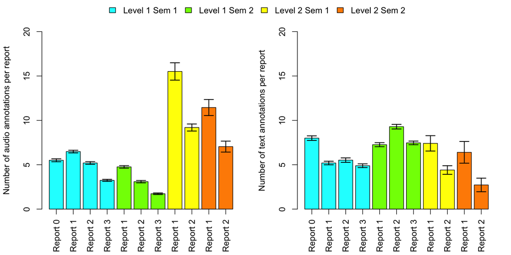

Figure 2: Number of audio and text annotations for level 1 course (Report 0: n=681, Report 1: n=1559, Report 2: n=1535, Report 3: n=1516) and for the level 2 course (Report 1: n=299, Report 2: n=295). Shown is the A) mean+/-SEM number of audio annotations per report across two semesters of level 1 and 2 subjects; B) mean+/-SEM number of text annotations per report across two semesters of level 1 and 2 subjects.

With the exception of the formative task, markers tended to provide more audio annotations on the earliest reports in each year and semester, with the amount of audio feedback provided then declining on subsequent reports across each semester (Figure 2A; p<0.001). Interestingly, despite this decline, the average length of each in situ audio annotation was relatively consistent, with averages across semesters and year levels *varying between 25.4+/-0.2 and 37.6+/-1.2 seconds per annotation* [?OR JUST GIVE OVERALL AVERAGE: 28.8+/-0.2 seconds per annotation]. With an average talking speed of 164 words/minute, this would suggest that markers tend to give feedback in approximately 80 word ‘sound bites’, effectively a short paragraph of information. This contrasts with other studies where a single audio annotation is given, as these tend to be considerably longer (Ribchester, France, and Wakefield 2008; Gould and Day 2013), but may equate to a similar amount of audio feedback being provided overall on equivalent tasks (Ice et al. 2010; Lunt and Curran 2010).

However, while audio annotations were relatively consistent in length, the typed annotations were not. The first year students in semester 1 received longer typed annotations on their early reports, with the longest typed comments appearing on the formative task (15.4+/-0.2 words) and declining thereafter (Report 1: 12+/-0.2 words; Report 2: 11+/-0.2 words; Report 3: 8.9+/-0.2 words; p<0.001; Figure 3). In semester 2, where no formative task existed, *the typed annotations were longer than for the equivalent task in the earlier semester but* [DELETE - NOT SIG DIFF BETWEEN SEMESTERS (P=0.153), AND NO SIG INTERACTION (P=0.0846)] declined in a similar way (Report 1: 12.2+/-0.2 words; Report 2: 10.4+/-0.1 words; Report 3: 8.8+/-0.1 words; p<0.001; Figure 3). *These differences between semesters suggest that there was an impact of the formative task.Potentially it gave markers an additional opportunity for feedback, allowing them to help the students to establish their writing skills early, then to focus on specific areas for improvement in latter tasks, whereas in the second semester these purposes had to be addressed across fewer tasks. This is supported by the finding that,* [DELETE - NOT SIG DIFF] Collectively, the amount of typed feedback provided across the first years’ reports was similar in each semester (Semester 1: 10.7+/-0.1 words; Semester 2: 10.5+/-0.1 words; p=0.157). *For the second years’ reports, the typed annotations were significantly fewer in number and shorter (Report 1: 7+/-0.2 words; Report 2: 6.7+/-0.3 words, p<0.001) than those provided on the first years’ reports.* [DELETE - REPEATS SECTION IN 2ND PARAGRAPH OF FEEDBACK PROVISION SECTION] For the second years’ reports, the number (Report 1: 28.1+/-25.4 words; Report 2: 33.7+/-37.6 words, p<0.001) and length (Report 1: 7+/-0.2 words; Report 2: 6.7+/-0.3 words, p<0.001) of typed annotations declined across the two reports. *This may reflect the preponderance of audio comments on the second years’ reports, with the brief typed comments likely to be primarily minor error corrections (Merry and Orsmond 2008).* [DELETE - NO LONGER SUPPORTED BY STAT’S]

The availability of in situ feedback possible with this marking tool was well utilised by markers, with annotations, whether typed or audio, being placed primarily in situ, and very few reports receiving ‘summary’ annotations either on the first (9%) or last (0.01%) page of the report text. This meant that each feedback annotation was placed near the specific portion of student work to which it referred. Previous studies using audio annotations have highlighted that the separation of comments from student work, for example when an overall audio comment is made or when audio and text files are separate, is viewed as a disadvantage by students (Ribchester, France, and Wakefield 2008; Rodway-Dyer, Dunne, and Newcombe 2009). In this regard, the advent of completely online assessment submission and marking systems, which allow the embedding of feedback regardless of modality, represent a notable improvement in feedback provision.

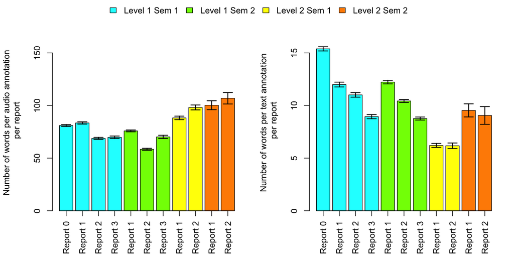

Figure 3: Number of words provided in each audio and text annotation for level 1 course (Report 0: n=681, Report 1: n=1559, Report 2: n=1535, Report 3: n=1516) and for the level 2 course (Report 1: n=299, Report 2: n=295). Shown is the A) mean+/-SEM number of words in each audio annotation in reports across two semesters and levels; B) mean+/-SEM number of words in each text annotation in reports across two semesters and two levels. *NB The y-axis scale for A is 10x the y-axis scale for B.*

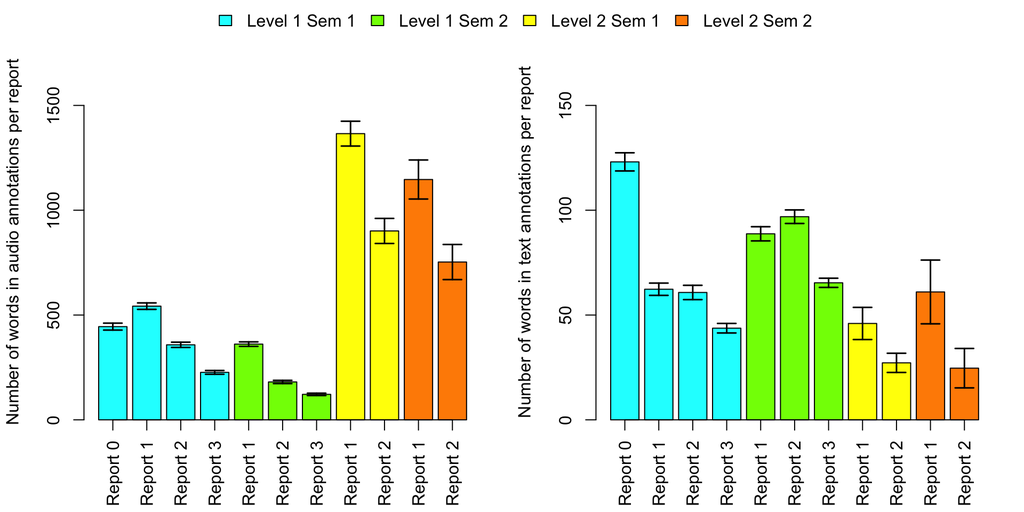

Figure 4: Total amount of feedback provided in audio and text feedback for level 1 course (Report 0: n=681, Report 1: n=1559, Report 2: n=1535, Report 3: n=1516) and for the level 2 course (Report 1: n=299, Report 2: n=295). Shown is the A) mean+/-SEM number of words in audio annotations in reports across two semesters and levels; B) mean+/-SEM number of words in text annotations in reports across two semesters and two levels. *NB The y-axis scale for A is 10x the y-axis scale for B.*

## Feedback use

*Proportion of students viewing report feedback*  
The vast majority of the first year students opened their marked reports (92%), although the proportion who did so tended to decline slightly across the semester, with the final report being opened by fewer students (83%; Figure 5). Surprisingly, the reverse was true in second year students. In comparison to the first year students, fewer second year students opened any of their reports (85%), with only 63% opening their first report, but 74% opening their second report, a similar proportion to the first year students. Notably this pattern was consistent in each semester (Figure 5). It is difficult to identify the cause of this difference between first and second year students, it may reflect a lower engagement with assessment by second year students (Loughlin et al. 2013) or could be that the additional opportunities that the they had during class to gain verbal feedback on their first report meant that they were less reliant on the feedback provided on the report documents.

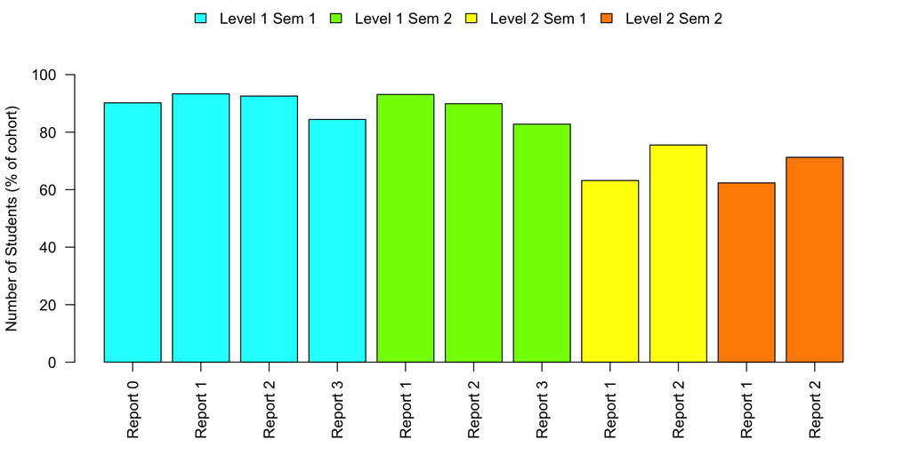

Figure 5: The proportion of students who looked at their feedback (shown as the proportion of students who received feedback in each cohort). Number of students in each cohort: Level 1 Semester 1: n=682; Level 1 Semester 2: n=897; Level 2 Semester 1: n=239; Level 2 Semester 2: n=85.

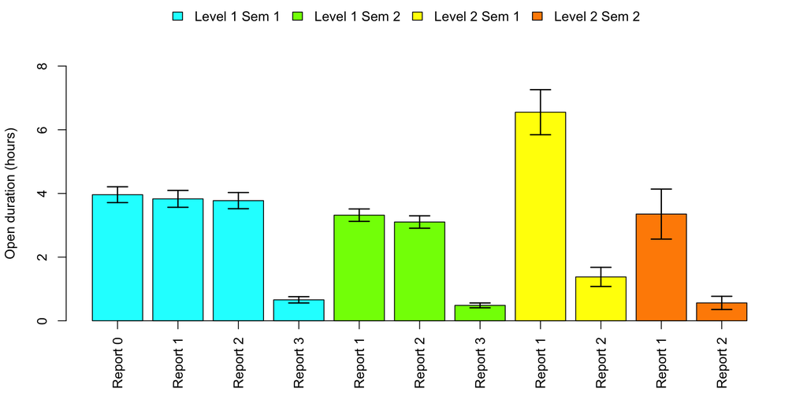

Figure 6: The duration students had their report feedback open for the level 1 course (Report 0: n=682, Report 1: n=1571, Report 2: n=1541, Report 3: n=1521) and for the level 2 course (Report 1: n=324, Report 2: n=321). Data are expressed as the mean+/-SEM time for which each report was open, in hours.

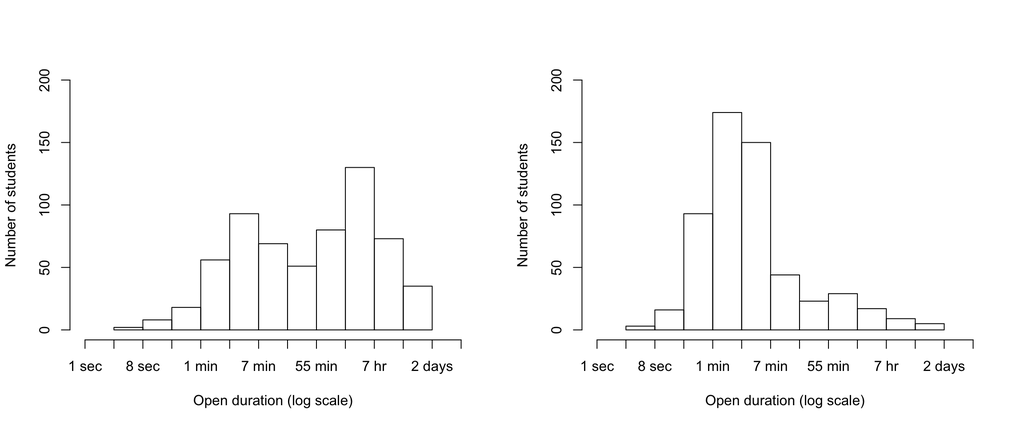

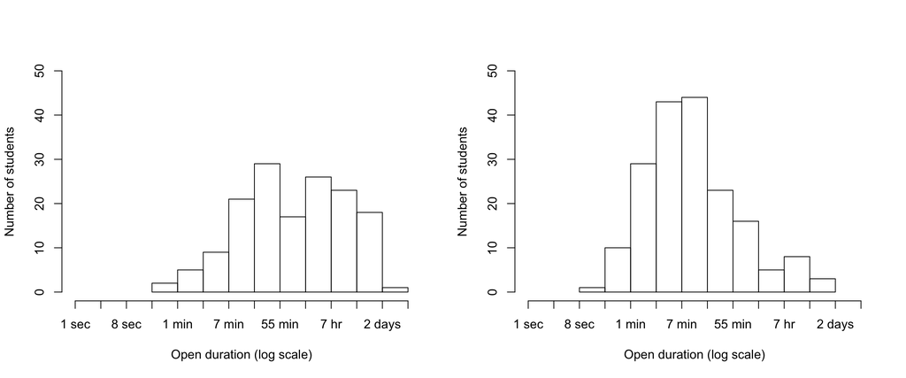

Figure 7: The number of students who had their feedback open for various durations following the Level 1 Semester 1 course A) formative report (Report 0: n=682), and B) final report (Report 3: n=667), and the Level 2 Semester 1 course C) first report (Report 1: n=239), and C) final report (Report 2: n=241). Data are presented as a frequency histogram showing the number of student across the log transformed open duration.

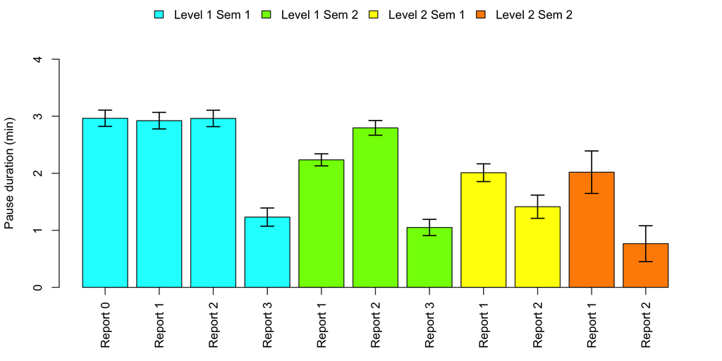

Figure 8: Duration for which students pause between clicks when interacting with feedback for the level 1 course (Report 0: n=682, Report 1: n=1571, Report 2: n=1541, Report 3: n=1521) and for the level 2 course (Report 1: n=324, Report 2: n=321). Data are expressed as the mean+/-SEM time that students paused between clicks for each report, in minutes

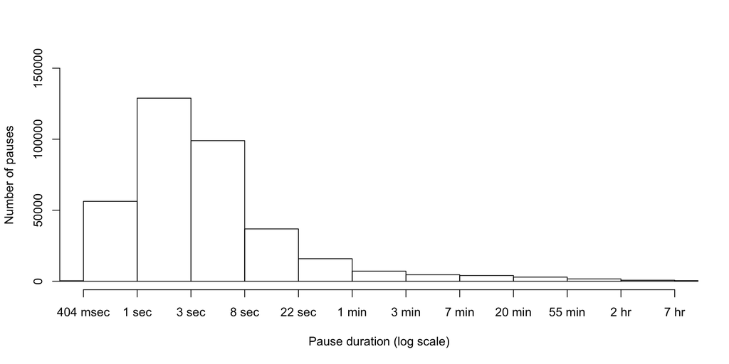

Figure 9: Frequency histogram of the duration students pause between clicks when interacting with feedback across the corpus of reports (n=5195 reports). Data are expressed as the number of times students paused between clicks for each duration (x scale is log transformed ranging from msec to hours).

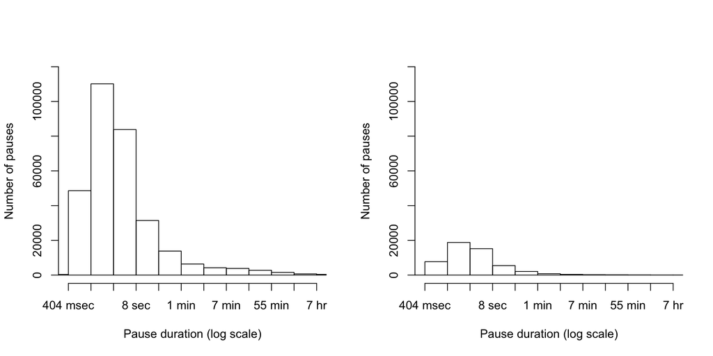

Figure 9: Frequency histogram of the duration students pause between clicks when interacting with feedback for the A) non-final reports (n=3686 reports) and B) final reports (n=1509 reports). Data are expressed as the number of times students paused between clicks for each duration (x scale is log transformed ranging from msec to hours).

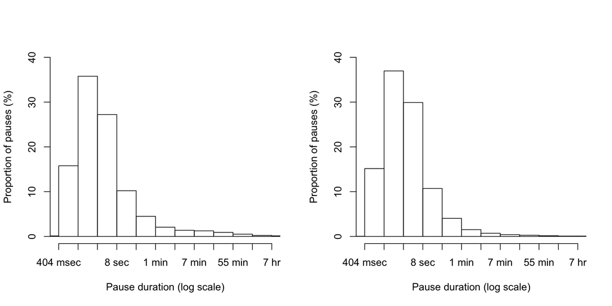

Figure 9: Frequency histogram of the duration students pause between clicks when interacting with feedback for the A) non-final reports (n=3686 reports) and B) final reports (n=1509 reports). Data are expressed as the proportion of pauses students took between clicks, ranging from milliseconds to hours (x scale is log transformed to improve clarity).

*checking number of clicks for final vs nonfinal*

Students interacted with their non-final reports to a significantly greater degree compared with their final reports for both the level 1 course (Report 1: 105+/-2 clicks per report; Report 3: 38+/-1 clicks per report; p<0.001) and the level 2 course (Report 1: 202+/-10 clicks per report; Report 2: 67+/-4 clicks per report; p<0.001).

## Academic Performance

Both first and second year students showed a steady improvement in their performance on each report within each semester (Figure 10), with the average achievement on each subsequent task being significantly higher than the preceding task (Level 1 Semester 1: p<0.001; Semester 2: p<0.001; Level 2: p<0.001). It should be noted that the performance on the first task in the second year course was significantly lower than that of the final report in the first year course (p<0.001). Potentially this reflects the increase in assessment complexity and expectations across the year levels (Colthorpe et al. 2015). Interestingly, the average performance for the first year students in each semester was comparable between the summative tasks (p=0.15), but their performance on the formative task in semester 1 was lower than any summative tasks, regardless of semester (p<0.001; Figure 10). This suggests that students in semester 2 are not disadvantaged by the lack of the formative task, potentially the experience they have gained in completing a semester prior to commencing this course has been an effective substitute for any learning gains from the formative task.

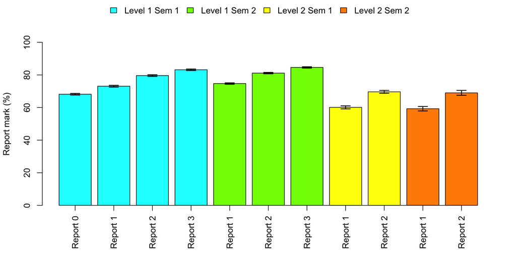

Figure 10: Overall final mark for reports in the level 1 course (Report 0: n=682, Report 1: n=1571, Report 2: n=1541, Report 3: n=1521) and for the level 2 course (Report 1: n=324, Report 2: n=321). Data are expressed as the mean+/-SEM mark that students achieved for each report, as a percentage.